```r
# if you want to preview this file,
# 1. specify doctype: "draft" or "slide"
# 2. replace knitr format = "html"
library(here); knitr::opts_knit$set(root.dir = here())
doctype <- "draft"
options(knitr.kable.NA = " ", knitr.table.format = "html")
knitr::opts_chunk$set(
  message = FALSE,
  warning = FALSE,
  echo = FALSE,
  cache = FALSE,
  include = TRUE
)
```

# Price Elasicity with Tax Report

In the previous section, the result shows that the size of estimated elasticity may vary depending on the estimation methods. This may be because the sample size is small compared to the extant research. However, our three robustness checks are in line with the baseline result, which shows that the price elasticity of intensive margin is less elastic than one of extensive margin. Thus, the obtained results suggest that the decision to donate is sensitive to the giving price, though the amount of donations is insensitive to the giving price once they decide to donate.

These results are obtained by ITT approach. This means that our estimates obtained in the previous section reflect not only the true price effect of tax incentive but also the effect of self-selection of applying for a tax deduction. Since the tax reform affects not only relative price of giving but also decision-making of a tax deduction, previous results have some policy implications. If we explicitly control the self-selection of a tax deduction, we may obtain further policy implications about tax incentive of charitable giving. In this section, we report results of the panel IV method which controlls the self-selection of a tax deduction.

## Instrumental Variable of Tax Deduction

Descriptive Statistics of Tax Deduction among Donors

| Year | Applying for a tax deduction Labor income | Applying for a tax deduction Labor and Total income | Not applying for a tax deduction Labor income | Not applying for a tax deduction Labor and Total income |
| --- | --- | --- | --- | --- |
| 2012 | 53 | 740 | 142 | 136 |
| 2013 | 67 | 778 | 157 | 156 |
| 2014 | 14 | 443 | 159 | 150 |
| 2015 | 21 | 520 | 199 | 191 |
| 2016 | 23 | 555 | 211 | 201 |
| 2017 | 17 | 657 | 224 | 211 |

Before describing the strategy of instrumental variable in detail, we show descriptive statistics of a tax deduction. NaSTaB asks respondents to answer whether to apply for a tax deduction in the case of labor income and total income separately. @ref(tab:SummaryDeduct) shows the number of tax deduct among donors in our sample.[^1] When we only use information about tax deduction in the case of labor income, the majority of respondents did not apply for a tax deduction (see the first and third column). When we use information about tax deduction in the case of both labor and total income, we make a dummy taking 1 if respondents applied for a tax deduction in the case of either labor or total income. As a result, more than half of respondents applied for a tax deduction.

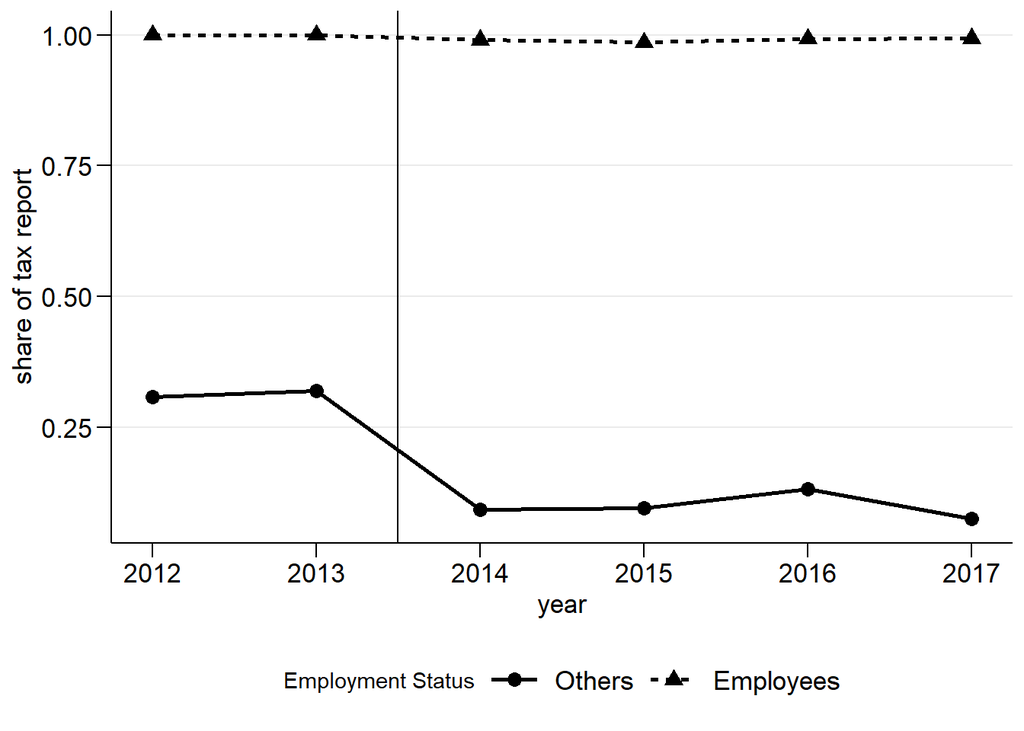

Proportion of Applying for a Tax Deduction Grouped by Employment Status. Notes: We restrict sample to those who donated.

If there is no (physical or psychological) cost to apply for a tax deduction, then all individuals should apply for a tax deduction. However, as shown in @ref(tab:SummaryDeduct), applying for a tax deduction may incur some costs because some respondents did not applied for a tax deduction. Employment status is one dimension of variation of applyed cost. Those who are employed in a firm can ask a firm to apply for a tax deduction instead, while those who are self-employed needs to apply for it by themselves. In fact, @ref(fig:DeductByEmployee) shows that the proportion of applying for a tax deduction among employee is higher than among others. Thus, we use employment status as an instrument of a tax deduction.

Our estimation strategy is the panel IV method. The equation of the first stage is as follows:

$$\begin{align}
R_{it}
= \alpha_{1i} + \lambda \text{Employee}_{it} + X_{it} \beta_1
+ \mu_{i1} + \iota_{t1} + \eta_{it} (\#eq:stage1)
\end{align}$$
where $R_{it}$ is a dummy of tax deduction, and $\text{Employee}_{it}$ is a dummy of employee. After estimating this equation, we calcluate the fitted value of $R_{it}$ denoted by $\hat{R}_{it}$. Using the fitted value $\hat{R}_{it}$, we estimat the following second-stage equation:

$$\begin{equation}
Y_{it} = \varepsilon^{int}_p \hat{R}_{it} \ln p^f_{it} + \varepsilon^{int}_y \ln y_{it}
+ X_{it}\beta +\mu_i +\iota_t +u_{it}. (\#eq:stage2)
\end{equation}$$
where $Y_{it}$ is an outcome variable. When we estimate the extensive-margin elasticity, an outcome variable $Y_{it}$ is a dummy of giving, $D_{it}$. When we estimate the intensive-margin elasticity, an outcome variable $Y_{it}$ is a logged value of giving, $\ln g_{it}$. The variable $\ln p^f_{it}$ is a first price of charitable giving to avoid the problem that giving price depends on charitable giving.

The instrumental vairbale $\text{Employed}_{it}$ must hold independence of $u_{it}$ conditional on covariates. There are two potential sources to violate this assumption. First, the employment status may produce income variation. If this is true, then the employment status affects charitable giving through income effect. Second, an opprtunity of giving may depend on employment status. For example, a doctor and a public servant may have more opprtunities to donate than others. If so, the instrument is correlated with $u_{it}$. To avoid this problem, we control the interaction between year dummies and industry dummies.

## Results

First-Stage Result: Effect of Employee on Tax Deduction

employee

0.508***

0.464***

0.457***

(0.047)

(0.049)

(0.050)

Individual and time FE

Y

Y

Y

log(income)

N

Y

Y

Age

N

Y

Y

Year x Education

N

Y

Y

Year x Gender

N

Y

Y

Year x Resident Area

N

Y

Y

Year x Dummy of industry

N

N

Y

N

11088

11085

10942

Adjusted R-squared

0.918

0.919

0.920

Notes: $^{*}$ $p &lt; 0.1$, $^{**}$ $p &lt; 0.05$, $^{***}$ $p &lt; 0.01$. Standard errors are clustered at individual level. When controlling age, we alson include its squared term.

Table @ref(tab:stage1Report) shows estimation results of the first stage. As a result, employed dummy is strongly positively correlated with applying for a tax deduction. In any specification, employed dummy increase the probability of tax deduction by more than 45 percent points. Moreover, the ratio of coefficient to standard error is greater than nine. This implies that F-statistics of instrument is greater than 81. Thus, our panel IV method does not have a weak instument problem. For the second stage, we obtain the prediceted value of $R_{it}$, using the model (3).

Second-Stage Result (Overall Price Elasticity)

Propensity of Deduction x log(first price)

-2.364***

-1.710***

-1.603***

(0.401)

(0.447)

(0.466)

Individual and time FE

Y

Y

Y

log(income)

N

Y

Y

Age

N

Y

Y

Year x Education

N

Y

Y

Year x Gender

N

Y

Y

Year x Resident Area

N

Y

Y

Year x Dummy of industry

N

N

Y

N

16946

16946

16946

Adjusted R-squared

0.511

0.513

0.514

Notes: $^{*}$ $p &lt; 0.1$, $^{**}$ $p &lt; 0.05$, $^{***}$ $p &lt; 0.01$. Standard errors are clustered at individual level. When controlling age, we alson include its squared term. Propensity of Deduction is the predicted value of $R_{it}$ calculated by the model (3) in Table @ref(tab:stage1Report).

intensive-margin elasticityのPanel IVの結果

- 個人固定効果を加えると、ITTとして想定した弾性値（-1 ~ -0.5%）と似たような結果を取る
- Intenstive-margin elasticityはtax reportをする人に特に影響を与えるのか？

Second-Stage Result (Intensive-Margin Price Elasticity)

Propensity of Report x log(first price)

-1.161***

-0.947***

-0.987***

(0.284)

(0.318)

(0.342)

Individual and time FE

Y

Y

Y

log(income)

N

Y

Y

Age

N

Y

Y

Year x Education

N

Y

Y

Year x Gender

N

Y

Y

Year x Resident Area

N

Y

Y

Year x Dummy of industry

N

N

Y

N

5840

5840

5840

Adjusted R-squared

0.696

0.698

0.697

Notes: $^{*}$ $p &lt; 0.1$, $^{**}$ $p &lt; 0.05$, $^{***}$ $p &lt; 0.01$. Standard errors are clustered at individual level. When controlling age, we alson include its squared term. Propensity of Deduction is the predicted value of $R_{it}$ calculated by the model (3) in Table @ref(tab:stage1Report).

Second-Stage Result (Extensive-Margin Price Elasticity)

Propensity of Deduction x log(first price)

-0.506***

-0.347***

-0.319***

(0.090)

(0.104)

(0.110)

Implied price elasticity

-1.469***

-1.008***

-0.926***

(0.262)

(0.301)

(0.320)

Individual and time FE

Y

Y

Y

log(income)

N

Y

Y

Age

N

Y

Y

Year x Education

N

Y

Y

Year x Gender

N

Y

Y

Year x Resident Area

N

Y

Y

Year x Dummy of industry

N

N

Y

N

16946

16946

16946

Adjusted R-squared

0.426

0.427

0.428

Notes: $^{*}$ $p &lt; 0.1$, $^{**}$ $p &lt; 0.05$, $^{***}$ $p &lt; 0.01$. Standard errors are clustered at individual level. When controlling age, we alson include its squared term. Propensity of Deduction is the predicted value of $R_{it}$ calculated by the model (3) in Table @ref(tab:stage1Report). The implied extensive-marign price elasticity is evaluated at the sample mean of $D_{ijt}$.

[^1]: Due to small sample, we rule out observations in 2018.